# bleedthrough correction

We get this by fitting regression lines. Note that the relationship changes after growth ceases, so we restrict our analysis to this part of growth.

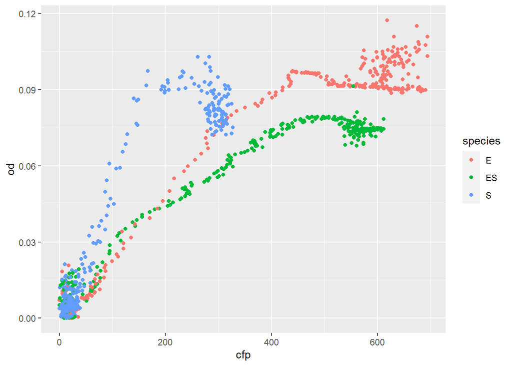

```r
results %>%
  ggplot(aes(x = cfp, y = od, color = species))+
  geom_point()
```

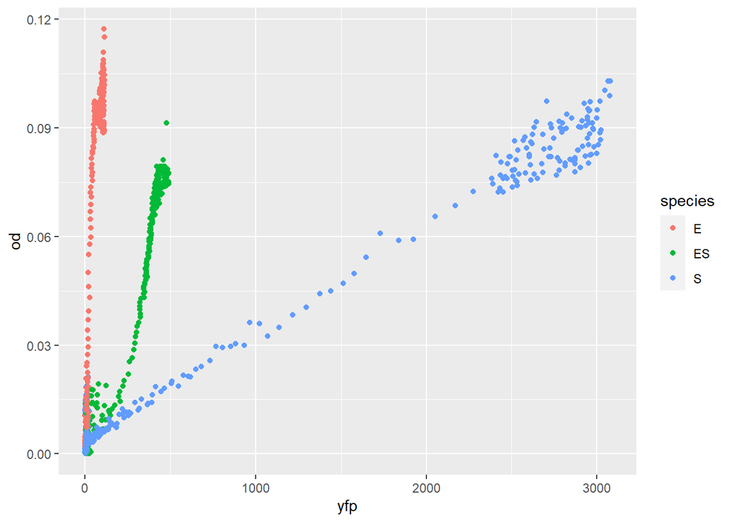

```r
results %>%
  ggplot(aes(x = yfp, y = od, color = species))+
  geom_point()
```

I wrote code which find the region of growth. It is old code and could easily be improved, but it works for now. The functions are in bleedthrough_funcs.r and can be used within a pipe. This chunk shows it plotted. The next one does the regression of OD vs. FP for these plots.

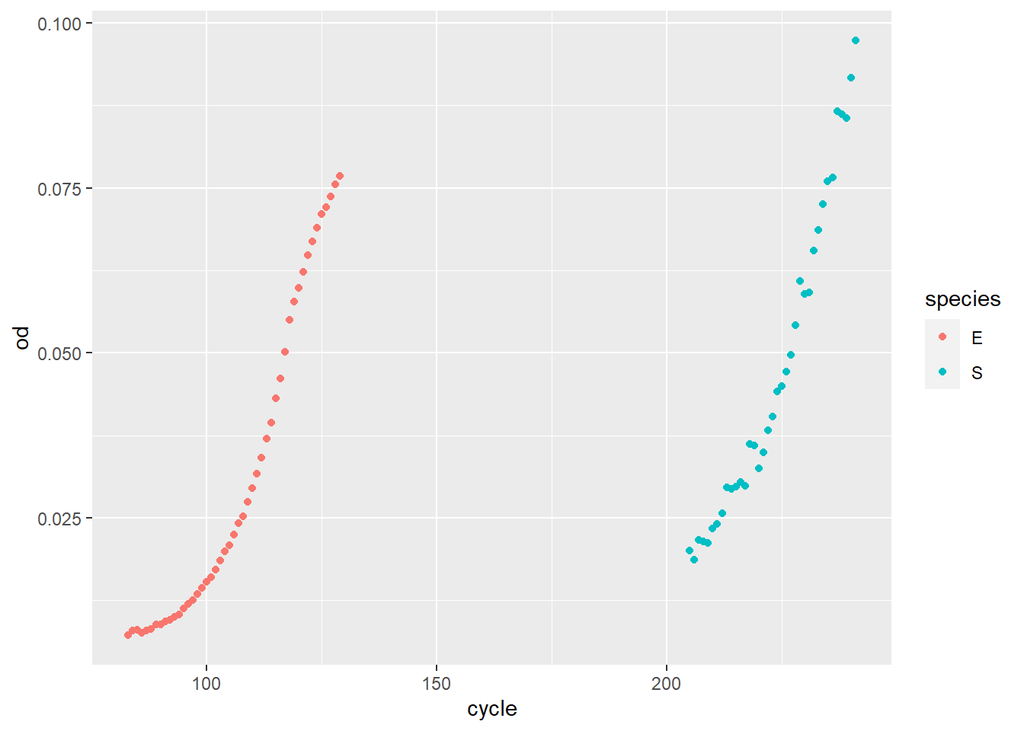

```r
source("./bleedthrough_funcs.r")
results %>%
  filter(species != "ES") %>%
  group_by(species) %>%
  filter(cycle >= get_start_growth_time(cycle, od) & cycle <= get_max_growth_time(cycle, od)) %>%
  ggplot(aes(x = cycle, y = od, color = species))+
  geom_point()
```

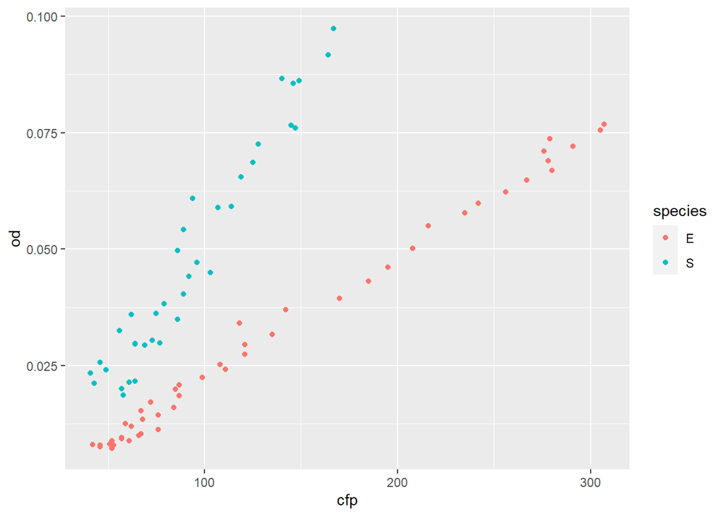

```r
results %>%
  filter(species != "ES") %>%
  group_by(species) %>%
  filter(cycle >= get_start_growth_time(cycle, od) & cycle <= get_max_growth_time(cycle, od)) %>%
  ggplot(aes(x = cfp, y = od, color = species))+
  geom_point()
```

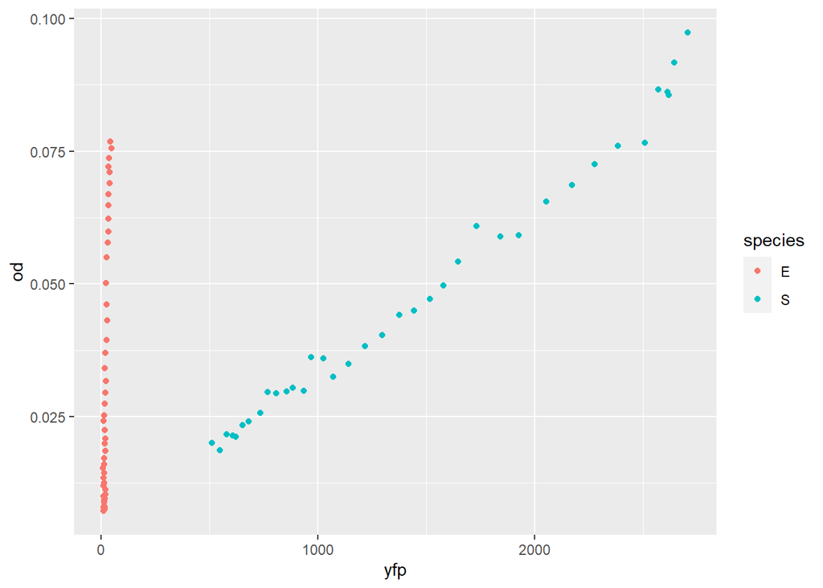

```r
results %>%
  filter(species != "ES") %>%
  group_by(species) %>%
  filter(cycle >= get_start_growth_time(cycle, od) & cycle <= get_max_growth_time(cycle, od)) %>%
  ggplot(aes(x = yfp, y = od, color = species))+
  geom_point()
```

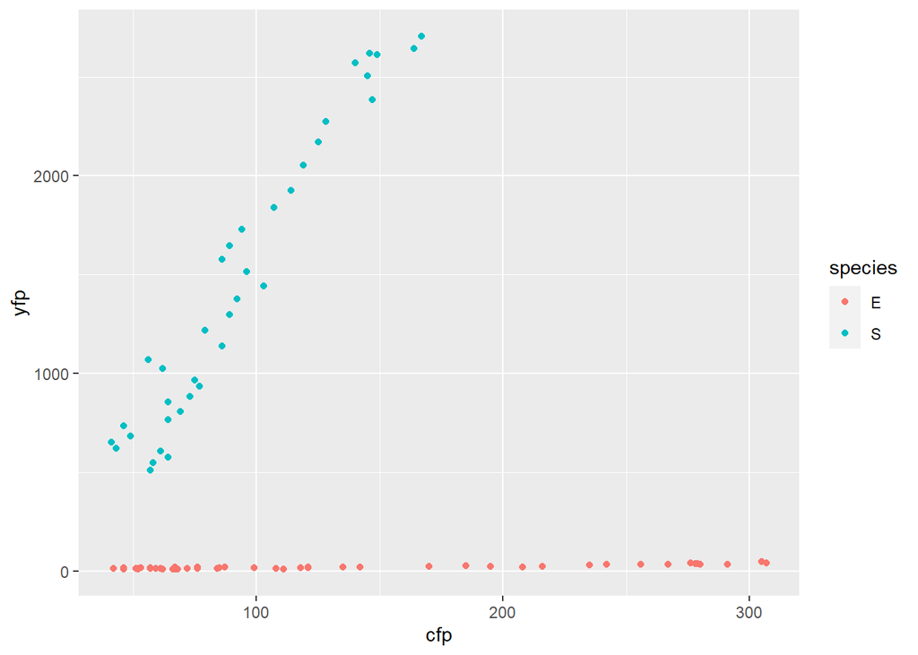

```r
results %>%
  filter(species != "ES") %>%
  group_by(species) %>%
  filter(cycle >= get_start_growth_time(cycle, od) & cycle <= get_max_growth_time(cycle, od)) %>%
  ggplot(aes(x = cfp, y = yfp, color = species))+
  geom_point()
```

Now we get the coefficients and put them into a table. if the regression is not significant, we disclude it. I am doing this “manually” to make it clearer what is happening, though one could put this into a pipe if desired.

```r
E_od_from_cfp = results %>%
  filter(species == "E") %>%
  filter(cycle >= get_start_growth_time(cycle, od) & cycle <= get_max_growth_time(cycle, od)) %>%
  summarize(slope = coef(lm(od ~ cfp))[2]) %>%
  select(slope) %>%  pull %>% unname
E_yfp_from_cfp = results %>%
  filter(species == "E") %>%
  filter(cycle >= get_start_growth_time(cycle, od) & cycle <= get_max_growth_time(cycle, od)) %>%
  # check for significance
  summarize(slope = ifelse(coef(summary(lm(yfp ~ cfp)))[2,4] < 0.05,
                           coef(lm(yfp ~ cfp))[2], 0)) %>%
  select(slope) %>% pull %>% unname
S_od_from_yfp = results %>%
  filter(species == "S") %>%
  filter(cycle >= get_start_growth_time(cycle, od) & cycle <= get_max_growth_time(cycle, od)) %>%
  summarize(slope = coef(lm(od ~ yfp))[2]) %>%
  select(slope) %>%  pull %>% unname
S_cfp_from_yfp = results %>%
  filter(species == "S") %>%
  filter(cycle >= get_start_growth_time(cycle, od) & cycle <= get_max_growth_time(cycle, od)) %>%
  # check for significance
  summarize(slope = ifelse(coef(summary(lm(cfp ~ yfp)))[2,4] < 0.05,
                           coef(lm(cfp ~ yfp))[2], 0)) %>%
  select(slope) %>% pull %>% unname
```

We compile these into a matrix which we use to solve a system of equations, which give us species-specific fluorescence values, which then can be multiplied to get species-specific OD values.

```r
fluorescence_matrix = matrix(c(1, S_cfp_from_yfp, E_yfp_from_cfp, 1), nrow = 2, byrow = TRUE)
print(fluorescence_matrix)
```

```
##           [,1]       [,2]
## [1,] 1.0000000 0.04826296
## [2,] 0.1027046 1.00000000
```

```r
results = results %>%
  rowwise() %>%
  mutate(E_cfp = solve(fluorescence_matrix, c(cfp, yfp))[1],
         S_yfp = solve(fluorescence_matrix, c(cfp, yfp))[2]) %>%
  mutate(E_od = E_cfp * E_od_from_cfp,
         S_od = S_yfp * S_od_from_yfp)
```

Now we have OD data on each species in the coculture, using fluorescence, with bleedthrough corrected for.

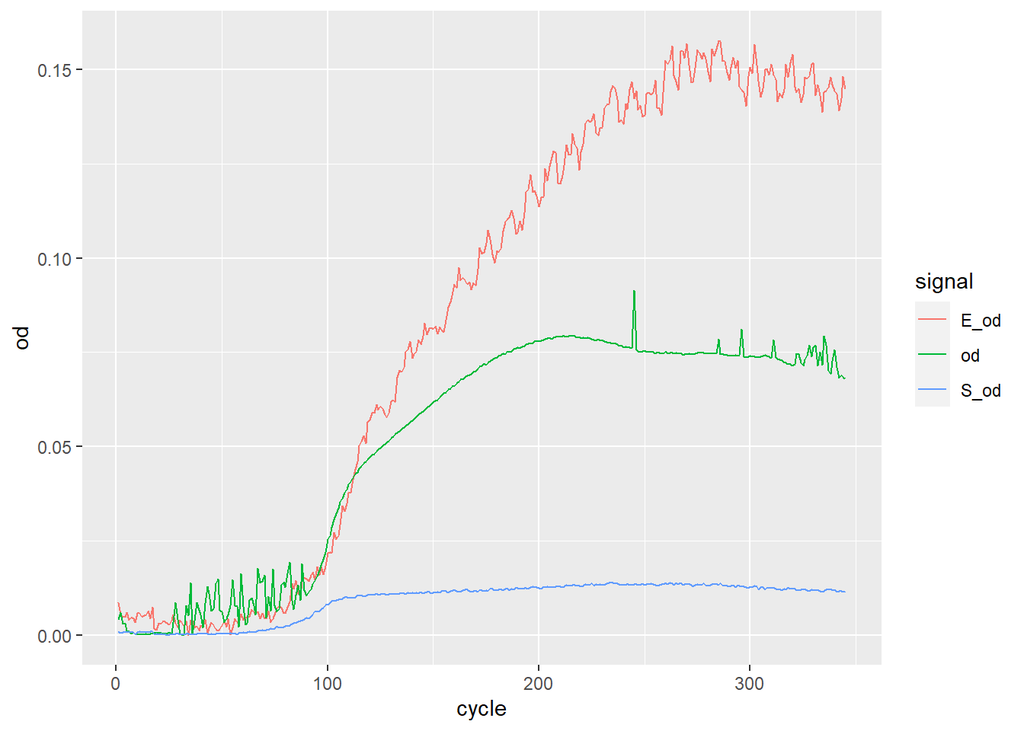

```r
results %>%
  filter(species == "ES") %>%
  pivot_longer(cols = c(od, E_od, S_od), names_to = "signal", values_to = "od") %>%
  ggplot(aes(x = cycle, y = od, color = signal))+
  geom_line()
```

Obviously, this particular example didn’t work that well–I’m time-strapped so didn’t want to spend a lot of time finding a good, representative case, but in general in good cases the species-specific ODs should sum (ish) to the actual OD.